# Modelado de datos para el análisis de redes en revistas colombianas de la primera mitad del siglo XX

Por:  
**Nancy Vargas Castro** (Universtität Tübingen)  
**Danilo Penagos Jaramillo** (Universidad de Antioquia UdeA)

## Bibliotecas o paquetes necesarios

## 1. Modelo de datos

### 1.1 Importación de los datos

```r
alpha <- read.csv("datos/revistas/Alpha_limpia.csv")
bohemia_alegre <- read.csv("datos/revistas/BohemiaAlegrelimpia.csv")
contemporanea <- read.csv("datos/revistas/Contemporanea_limpia.csv")
cultura <- read.csv("datos/revistas/Culturalimpia.csv")
montannes <- read.csv("datos/revistas/ElMontañeslimpia.csv")
repertorio <- read.csv("datos/revistas/ElRepertoriolimpia.csv")
gruta <- read.csv("datos/revistas/LaGrutalimpia.csv")
lectura_amena <- read.csv("datos/revistas/Lectura_Amenalimpia.csv")
lectura_arte <- read.csv("datos/revistas/Lecturartelimpia.csv")
literaria <- read.csv("datos/revistas/Literarialimpia.csv")
moderna <- read.csv("datos/revistas/Modernalimpia.csv")
panida <- read.csv("datos/revistas/Panidalimpia.csv")
trofeos <- read.csv("datos/revistas/Trofeoslimpia.csv")
```

### 1.2. Selección variables de interés

Seleccionamos de nuestros modelos solo las variables que nos interesan para hacer un primer análisis de la red. A saber: nombre de la revista, coloaborador, rol, seudónimo, país de origen, título, tipo.

```r
alpha <- alpha |>
  select(NombreR, Colaborador, Roles, Seudonimo, PaisOrigen, Titulo, Tipo)

bohemia_alegre <- bohemia_alegre  |>
  select(NombreR, Colaborador, Roles, Seudonimo, PaisOrigen, Titulo, Tipo)

contemporanea <- contemporanea  |>
  select(NombreR, Colaborador, Roles, Seudonimo, PaisOrigen, Titulo, Tipo)

cultura <- cultura  |>
  select(NombreR, Colaborador, Roles, Seudonimo, PaisOrigen, Titulo, Tipo)

gruta <- gruta  |>
  select(NombreR, Colaborador, Roles, Seudonimo, PaisOrigen, Titulo, Tipo)

lectura_amena <- lectura_amena  |>
  select(NombreR, Colaborador, Roles, Seudonimo, PaisOrigen, Titulo, Tipo)

lectura_arte <- lectura_arte  |>
  select(NombreR, Colaborador, Roles, Seudonimo, PaisOrigen, Titulo, Tipo)

literaria <- literaria  |>
  select(NombreR, Colaborador, Roles, Seudonimo, PaisOrigen, Titulo, Tipo)

moderna <- moderna  |>
  select(NombreR, Colaborador, Roles, Seudonimo, PaisOrigen, Titulo, Tipo)

montannes <- montannes  |>
  select(NombreR, Colaborador, Roles, Seudonimo, PaisOrigen, Titulo, Tipo)

panida <- panida  |>
  select(NombreR, Colaborador, Roles, Seudonimo, PaisOrigen, Titulo, Tipo)

repertorio <- repertorio  |>
  select(NombreR, Colaborador, Roles, Seudonimo, PaisOrigen, Titulo, Tipo)

trofeos <- trofeos  |>
  select(NombreR, Colaborador, Roles, Seudonimo, PaisOrigen, Titulo, Tipo)
```

### 1.3. Creación data set `revistas`

Creamos un data set único llamado `revistas` con todas nuestros modelos reducidos.

[output not shown]

Visualizamos las primeras filas en una tabla.

| ID | Nombre de la revista | Autor | Rol | Seudónimo | País de Origen | Título | Tipo de texto |
| --- | --- | --- | --- | --- | --- | --- | --- |
| 1 | Alpha | Carrasquilla, Tomás | Creador |  | Colombia | Homilia N.°I. | Prosa No ficción |
| 2 | Alpha | Schiller, Friedrich | Creador |  | Alemania | El guante | Poesía |
| 3 | Alpha | Villiers de L'Isle-Adam, Auguste de | Creador |  | Francia | Vox Populi | Prosa Ficción |
| 4 | Alpha | Uribe, Joaquín Antonio | Creador |  | Colombia | Cuadros de la Naturaleza. Las Hormigas | Prosa Ficción |
| 5 | Alpha | Gaviria, José A. | Creador |  | Colombia | Napoles (de una cartera de viajes) | Prosa Ficción |
| 6 | Alpha | Altenberg, Peter | Creador |  | Austria | Doce Años | Prosa Ficción |
| 7 | Alpha | Directores | Director |  | Colombia | Crónica literaria | Prosa No ficción |
| 8 | Alpha | Directores | Director |  | Colombia | Crónica literaria | Reseña |
| 9 | Alpha | Directores | Director |  | Colombia | Crónica literaria | Reseña |
| 10 | Alpha | Directores | Director |  | Colombia | Crónica literaria | Prosa No ficción |

[output cut: 4457 more lines]

## 2. Frecuencia colaboradores

### 2.1. Creación de la tabla de frecuencia de colaboradores

Aquí, creamos una tabla de datos con el cálculo de la frecuencia de colaboradores en todo nuestro modelo de 13 revistas. Esta tabla incluye las variables `Colaborador` y `Frecuencia`

```r
colaboradores_revistas <- as.data.frame(table(revistas$Colaborador))
colaboradores_revistas <- colaboradores_revistas[order(colaboradores_revistas$Freq, decreasing = T), ]
colnames(colaboradores_revistas) <- c("Colaborador", "Frecuencia")

# 938 colaboradores en lista


# Guardamos para revisar manualmente que no haya errores
#write.csv(conlaboradores_revistas, file = "ColaboradoresRevistas.csv", fileEncoding = "UTF-8", #row.names=FALSE)
```

Obtenemos, de este modo, una tabla con **938** entradas. Visualizamos las primeras 10.

|  | Colaborador | Frecuencia |
| --- | --- | --- |
| 20 | Anónimo | 746 |
| 427 | La dirección | 247 |
| 741 | Rodríguez, Horacio Marino | 123 |
| 349 | Greiff, Luis de | 87 |
| 436 | Laverde Amaya, Isidoro | 77 |
| 115 | Cano, Francisco Antonio | 63 |
| 713 | Restrepo, Saturnino | 59 |
| 839 | Tobón Mejía, Marco | 57 |
| 779 | Sanín Cano, Baldomero | 46 |
| 600 | Ospina Vásquez, Mariano | 40 |

[output cut: 928 more lines]

### 2.2. Limpieza de anónimos y autorías colectivas

Como se observa en la tabla anterior, hay más de 700 registros cuyo colaborador es un “Anónimo”. También, hay algunas autorías colectivas que no se han desagregado en los respectivos nombres a cargo de la revista, y otras que es imposible determinar la autoría pues son textos que se publican de otros periódicos o revistas. Para este análisis se descartan. Nos quedamos así con **928** entradas.

### 2.3. Modelo de datos colaboradores

#### 2.3.1. Importación modelo de datos colaboradores.

Aquí, importamos el modelo de datos de colaboradores ya identificados. De este modelo nos interesan las variables : `Colaborador`, `Fuente`, `Seudonimo`, `Sexo`, `PaisOrigen`, `Nacimiento` y `Muerte`.

```r
colaboradores_BD <- read.csv("datos/colaboradores-bd.csv", header = T, encoding = "UTF-8", stringsAsFactors = FALSE)

# Reducimos la información a las variables esenciales
colaboradores_BD <- colaboradores_BD[,-c(8:25)]

# Renombramos las columnas
names(colaboradores_BD) <- c("Colaborador", "Fuente", "Seudonimo", "Sexo", "PaisOrigen","Nacimiento", "Muerte")
```

### 2.4. Comparación de los dos modelos

En este punto, el objetivo es comparar el modelo de contribudores limpio (con datos biográficos) y el modelo de las 13 revistas con las que estamos trabajando.

```r
colabs_no_encontrados <- anti_join(colaboradores_revistas, colaboradores_BD, by = "Colaborador")
# 359 diferencias

#write.csv(colabs_not_found, file = "ColabsNotFound.csv", fileEncoding = "UTF-8", row.names = F)
```

Con esta comparación obtenemos una tabla con los autores que todavía no han sido identificados hasta ahora en la recolección de datos o con los que todavía no han sido ingresados a esta, a pesar que ya tienen información biográfica disponible.

Esta tabla se puede guardar para hacer correcciones y buscar más información sobre estos autores.

|  | Colaborador | Frecuencia |
| --- | --- | --- |
| 1 | Montoya, Gabriel | 28 |
| 2 | Mejía Arango, Félix | 14 |
| 3 | Ruíz, Dael | 12 |
| 4 | Coradine, Alberto | 11 |
| 5 | Montoya Pérez, Rafael | 11 |
| 6 | Montoya, José | 11 |
| 7 | Carvajal, M.A. | 10 |
| 8 | Valderrama, Felipe | 10 |
| 9 | Escovar, José María | 8 |
| 10 | Vasco, Eduardo | 7 |

[output cut: 349 more lines]

### 2.5. Colaboradores identificados

Luego, procedemos a crear una tabla con los autores que sí han sido indentificados. Con estos es con los cuales trabajaremos en nuestro análisis de redes. En este caso tenemos **569** entradas. Guardamos este archivo en un .csv para usos posteriores.

```r
colabs_encontrados <- semi_join(colaboradores_revistas, colaboradores_BD, by="Colaborador")
# Al menos 569 entradas

# write.csv(revistas, file = "AllRevistas.csv", fileEncoding = "UTF-8", row.names = F)
```

|  | Colaborador | Frecuencia |
| --- | --- | --- |
| 1 | Rodríguez, Horacio Marino | 123 |
| 2 | Greiff, Luis de | 87 |
| 3 | Laverde Amaya, Isidoro | 77 |
| 4 | Cano, Francisco Antonio | 63 |
| 5 | Restrepo, Saturnino | 59 |
| 6 | Tobón Mejía, Marco | 57 |
| 7 | Sanín Cano, Baldomero | 46 |
| 8 | Ospina Vásquez, Mariano | 40 |
| 9 | López, Ismael | 38 |
| 10 | Grillo, Maximiliano | 37 |

[output cut: 559 more lines]

En este punto, creamos un *dataset* único con la información de la base de autores identificados y con los datos de nuestros modelos. Con este podremos observar algunos datos de interés como puede ser el país de origen de los colaboradores, el sexo, los tipos de textos, los roles, etc.

```r
# Creamos un índice para nuestro modelo de revistas
revistas$ID <- 1:nrow(revistas)

# Unimos los dos data sets, seleccionando la columna "Colaborador" para que
# sea la que una ambos archivos
m_revistas_colabs_BD <- merge(revistas, colaboradores_BD, by = "Colaborador", all.x = T)

# Ahora reordenamos las columnas sacando, además las columnas país de origen de
# los modelos y los seudónimos (de la base de datos de colaboradores)
m_revistas_colabs_BD <- m_revistas_colabs_BD[,c(8, 1, 3, 10:14, 2, 6, 7)]

# Ordenamos las entradas por el índice
m_revistas_colabs_BD  <- m_revistas_colabs_BD [order(m_revistas_colabs_BD$ID, decreasing = FALSE), ]

# Cuando esta ordenado, eliminamos los índice de los dataframe
# "revistas" y "m_revistas_colabs_BD"
revistas$ID <- NULL
m_revistas_colabs_BD$ID <- NULL


# Guardamos el resultado
# write.csv(m_revistas_colabs_BD, file = "RevistasDatosContributores.csv", fileEncoding = "UTF-8", row.names=FALSE)
```

## 3. Visualización de datos

### 3.1 Colaboradores con mayor número de contribuciones

Esta información la podemos ver representada en la Figura 1.

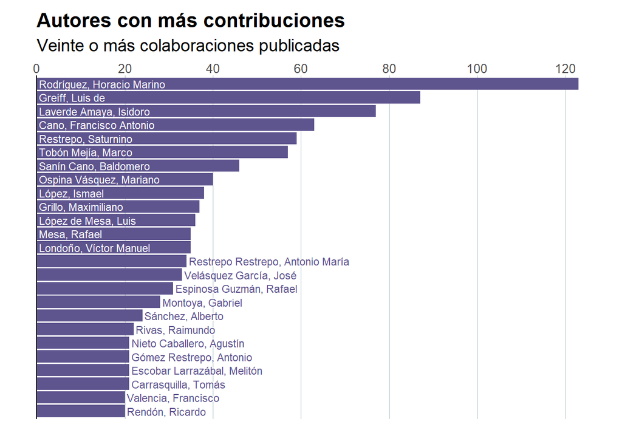

### 3.2 Colaboradores mejor conectados

```r
# Seleccionamos de nuestra variable "revistas", los colaboradores y los nombres
# de la publicación
colabs_completo <- select(revistas, Colaborador, NombreR)

# Luego contamos en cuantas publicaciones tiene el autor en cada revista
conexion_colab_revistas <- count(colabs_completo, Colaborador, NombreR)

# Guardamos los datos con solo del autor y la revista
conexion_colab <- conexion_colab_revistas[,c(1,2)]

# Ahora, agrupamos por colaborador, sumando total de revistas en las que apareció
conexion_colab %>%
  group_by(Colaborador) %>%
  summarise(n_distinct(NombreR)) -> conexion_colab_revistas
# Ordenamos los datos de forma decreciente
conexion_colab_revistas <- conexion_colab_revistas[order(conexion_colab_revistas$`n_distinct(NombreR)`, decreasing = T), ]

# Eliminanos los anónimos y las autorías múltiples
conexion_colab_revistas <- conexion_colab_revistas[conexion_colab_revistas$Colaborador != "Anónimo", ]
conexion_colab_revistas <- conexion_colab_revistas[conexion_colab_revistas$Colaborador != "Directores", ]
conexion_colab_revistas <- conexion_colab_revistas[conexion_colab_revistas$Colaborador != "Directores", ]
conexion_colab_revistas <- conexion_colab_revistas[conexion_colab_revistas$Colaborador != "Redacción", ]
conexion_colab_revistas <- conexion_colab_revistas[conexion_colab_revistas$Colaborador != "Le Temps", ]
conexion_colab_revistas <- conexion_colab_revistas[conexion_colab_revistas$Colaborador!= "Colombia, Congreso de", ] # 1 removed
conexion_colab_revistas <- conexion_colab_revistas[conexion_colab_revistas$Colaborador != "La redacción", ] # 1
conexion_colab_revistas <- conexion_colab_revistas[conexion_colab_revistas$Colaborador != "Review of Revieus", ] # 1 removed
conexion_colab_revistas<- conexion_colab_revistas[conexion_colab_revistas$Colaborador != "Reyes Católicos", ] # 1 removed
conexion_colab_revistas <- conexion_colab_revistas[conexion_colab_revistas$Colaborador != "Vicepresidente", ] # 1 removed

# Finalmente, extraemos los 24 mejor conectados
colabs_mejor_conectados <- conexion_colab_revistas[1:24,]
names(colabs_mejor_conectados) <- c("Colaborador", "Nro_conexiones")
```

Presentamos los resultados en la Figura 2.

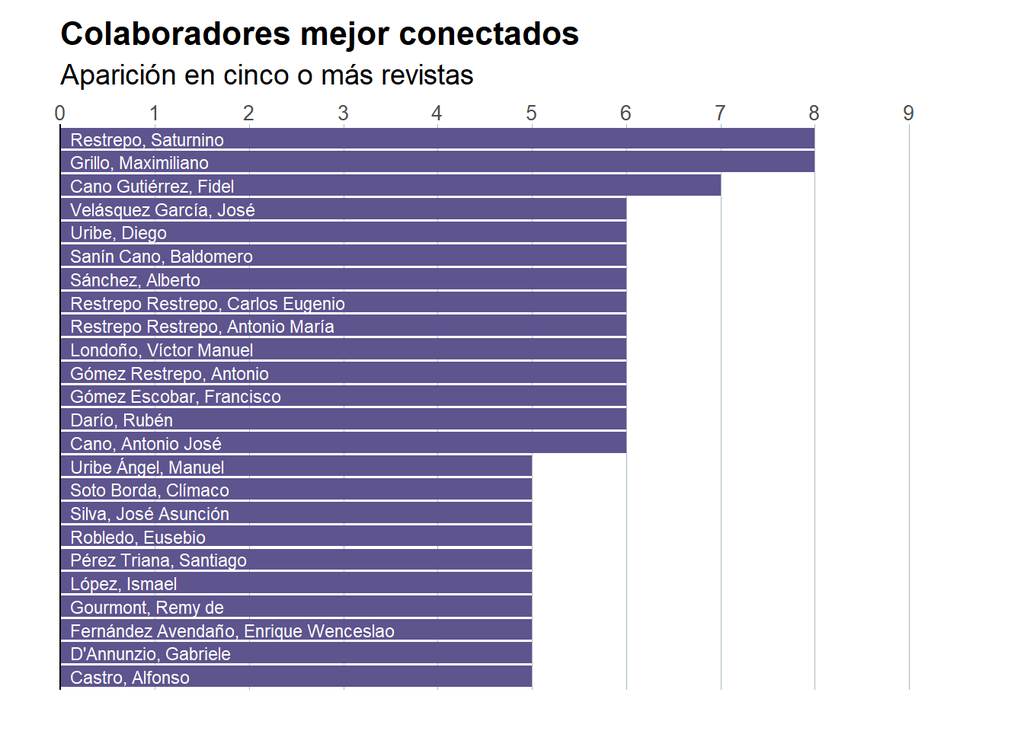

## 4. Una acercamiento con métodos del Social Network Analysis

A continuación, proponemos un análisis y visualización de los datos de las revistas basado en un enfoque relacional. Para ello partimos de la idea de que las revistas tiene agencialidad y se pueden considerar nodos dentro de la red. Las relaciones (aristas o edges) que se establecen son de revista a coloborador, y el peso de la relación esta dado por el número de contribuciones que publica la revista de cada autor.

```r
# Primero creamos una lista de aristas para obtener todas los enlaces
aristas_completo <- select(revistas, Colaborador, NombreR)

# Ahora creamos una lista de aristas con los pesos y la estructura from / to / n
aristas_completo <- count(aristas_completo, NombreR, Colaborador)
colnames(aristas_completo)[1] <- "from"
colnames(aristas_completo)[2] <- "to"
colnames(aristas_completo)[3] <- "n"

# Descartamos todas las entradas con autorías colectivas, así como los anónimos
aristas_completo <- aristas_completo[aristas_completo$to != "Anónimo", ] # 12 removed
aristas_completo <- aristas_completo[aristas_completo$to != "La dirección", ]
aristas_completo <- aristas_completo[aristas_completo$to != "Directores", ]
aristas_completo <- aristas_completo[aristas_completo$to != "Redacción", ]
aristas_completo <- aristas_completo[aristas_completo$to != "Le Temps", ]
aristas_completo <- aristas_completo[aristas_completo$to != "Colombia, Congreso de", ] # 1 removed
aristas_completo <- aristas_completo[aristas_completo$to != "La redacción", ] # 1
aristas_completo <- aristas_completo[aristas_completo$to != "Review of Revieus", ] # 1 removed
aristas_completo <- aristas_completo[aristas_completo$to != "Reyes Católicos", ] # 1 removed
aristas_completo <- aristas_completo[aristas_completo$to != "Vicepresidente", ] # 1 removed

# Guardamos el resultado
#write.csv(aristas_completo, file = "AristasRevistasColombianas.csv", fileEncoding = "UTF-8", row.names=FALSE)
```

El resultado de ello es una red bimodal o bipartita con dos tipos de nodos: “Revistas” y “Personas”. La estructura de este conjunto de datos es:

- id (i.e. nombre de los nodos)
- n (número de contribuciones)
- tipo (“Revista” o “Persona”)

```r
# De la lista de aristas creamos los nodos
nodos_completo <- aggregate(n ~ to, data=aristas_completo, FUN=sum)

# Añadimos la columna "tipo"
nodos_completo <- cbind(tipo = "Persona", nodos_completo)

# Reordenamos nuestro conjunto de datos
nodos_completo <- nodos_completo[,c(2,3,1)]
colnames(nodos_completo)[1] <- "id"

# ¿Cuántos coloboradores tiene cada revista?
revistas_conteo_colaboradores <- count(aristas_completo, from)
revistas_conteo_colaboradores <- cbind(tipo = "Revista", revistas_conteo_colaboradores)
revistas_conteo_colaboradores <- revistas_conteo_colaboradores[,c(2,3,1)]
colnames(revistas_conteo_colaboradores)[1] <- "id"
colnames(revistas_conteo_colaboradores)[2] <- "n"

# Convertimos la columna tipo a carácteres
nodos_completo$tipo <- as.character(nodos_completo$tipo)
class(nodos_completo$tipo) # Debe mostrar "character"
```

```
## [1] "character"
```

```r
# Hacemos los mismo para el caso de las revistas
revistas_conteo_colaboradores$tipo <- as.character(revistas_conteo_colaboradores$tipo)
class(revistas_conteo_colaboradores$tipo) # Debe mostrar "character"
```

```
## [1] "character"
```

```r
# bind the two dataframes together
nodos_completo <- rbind(revistas_conteo_colaboradores, nodos_completo)

# Guardamos el resultado
#write.csv(nodos_completo, file = "NodosRevistasColombianas.csv", fileEncoding = "UTF-8", row.names=FALSE)
```

Ahora bien, para el análisis cuantitivo creamos una lista de nodos adicionales. La estructura de datos de este set de datos tiene las siguiente variables:

- id (un identificador)
- nombre (nombre de los nodos)
- tipo (“Revista” o “Persona”)
- peso (el número de nodos (*weight*))

```r
nodos_completo_alt <- nodos_completo

# Renombramos la primera columna a "name"
colnames(nodos_completo_alt)[1] <- "name"

# Renombramos la segunda columna a  "weight"
colnames(nodos_completo_alt)[2] <- "weight"

# Agregamos un índice
nodos_completo_alt$id <- 1:nrow(nodos_completo_alt)

# Reordenamos el dataframe y descartamos la columna tipo
nodos_completo_alt <- nodos_completo_alt[,c(4,1,2)]

# Guardamos el resultado
# write.csv(nodos_completo_alt, file = "NodosCompletosAlternativos.csv", fileEncoding = "UTF-8", row.names=FALSE)
```

Para la visualización interactiva creamos una tabla de nodos y una tabla de aristas con la siguiente estructura:

- id (el índice o identificador)
- vertex (el nombre de los nodos)
- nsum (la suma total de publicaciones)

```r
# Esta lista de nodos es necesaria para la visualización interactiva con pesos
nodos_suma_colaboraciones <- nodos_completo

# Renombramos la primera columna como "vertex"
colnames(nodos_suma_colaboraciones)[1] <- "vertex"

# Renombramos la segunda columna como "nsum"
colnames(nodos_suma_colaboraciones)[2] <- "nsum"

# Añadimos un índice
nodos_suma_colaboraciones$id <- 1:nrow(nodos_suma_colaboraciones)

# Reordenamos el dataframe
nodos_suma_colaboraciones <- nodos_suma_colaboraciones[,c(4,1,3,2)]

# Creamos una lista alternativa de aristas y otra de nodos
# para calcular algunas medidas en nuestra red bimodal

lista_aristas <- aristas_completo
lista_nodos <- nodos_suma_colaboraciones

colnames(lista_aristas)[1] <- "source" # Renombramos la columna "from" to "source"
colnames(lista_aristas)[2] <- "target" # Renombramos la columna "to" to "target"

# Esto evita la confusión en los nombres de columna

# Seguido creamos una variabale para remplazar los nombres en la columna
# "from" con los ids en una tabla de aristas
aristas_id <- lista_aristas |>
  left_join(lista_nodos, by = c("source" = "vertex")) |>
  rename(from = id)

aristas_id <- aristas_id |>
  left_join(lista_nodos, by = c("target" = "vertex")) %>%
  rename(to = id)

# Nuevamente, ambas tablas se combinan;
# en el proceso, se comparan tanto las columnas de aristas "target" (de la lista de aristas)
# como las de vértices (de la lista de nodos).
# En el segundo paso, la columna "id" se renombra, esta vez,
# a "to".
# Ahora hay 9 columnas.

# Ahora seleccionamos las 3 columnas con los ID y el número de contribuciones
aristas_id <- select(aristas_id, from, to, n)

 # Si queremos comprabar que todo salio bien imprimimos el encabezado
# head(aristas_id)

# Renomsbramos las columnas de esta tabla
colnames(aristas_id) <- c("V1","V2","weight")
```

### 4.1 Cálculo de la *betweenness*

Mientras que los autores con mayor vínculos se determinaron por el número absoluto de apariciones en las revistas, ahora calcularemos la *betweenness* que tiene cada revista. Para ello utilizamos la biblioteca `tnet` creada para trabajar con redes bimodales, como la nuestra.

```r
# Primero calculamos la centralidad para una red bimodal con pesos
# con la biblioteca 'tnet'
net <- as.tnet(aristas_id, type = "weighted two-mode tnet")


# Ahora calculamos el grado bimodal (two modo degree)
out <- degree_tm(net, measure="degree")

# Ponemos un nombre a la columna
colnames(out)[2] <- "grado bimodal"

# Creamos una proyección de red monomodal
net1 <- projecting_tm(net, "Newman")

# Calculamos el grado de esta red
tmp <- degree_w(net1)[,"degree"]

# Añadimos los datos a la tabla
out <- data.frame(out, projecteddegree=tmp)

# Calculamos la "betweenness"
tmp <- betweenness_w(net1)[,"betweenness"]
out <- data.frame(out, projectedbetweenness=tmp)

# De nuestro conjunto de nodos seleccionamos el nombre
nodos_completo_alt |>
  select(name) -> nodename

# Lo agregamos a nuestro resultado
out[,"node"] <- nodename

# Guardamos el resultado
# write.csv(out, file = "WeightedTWoModeNet-ComparisonDegree.csv", fileEncoding = "UTF-8", row.names=FALSE)
```

El resultado lo podemos ver en la siguiente tabla:

|  | node | grado.bimodal | projecteddegree | projectedbetweenness |
| --- | --- | --- | --- | --- |
| 1 | Alpha | 131 | 12 | 32 |
| 2 | Cultura | 103 | 12 | 5 |
| 3 | El Montañés | 69 | 12 | 27 |
| 4 | El Repertorio. Revista Mensual Ilustrada | 78 | 12 | 24 |
| 5 | La Bohemia Alegre | 33 | 10 | 0 |
| 6 | La Gruta | 82 | 11 | 0 |
| 7 | Lectura Amena | 150 | 12 | 34 |
| 8 | Lectura y Arte | 83 | 12 | 13 |
| 9 | Panida | 68 | 12 | 0 |
| 10 | Revista Contemporánea | 66 | 12 | 0 |

[output cut: 3 more lines]

### 4.2. Cálculo de la modularidad

Ahora procedemos al cálculo de la modularidad en nuestro conjunto de trece revistas. Esto lo hacemos utilizando el algoritmo `cluster_walktrap`. Recuperamos para este próposito las variables `lista de nodos` y `aristas_id`. Con la biblioteca `igraph` convertimos nuestros nodos y nuestras aristas en una grafo.

```r
nodos_visualizacion <- lista_nodos
aristas_visualizacion <- aristas_id

# Cambiamos el nombre de las columnas
names(aristas_visualizacion) <- c("from", "to", "weight")

# Creamos nuestro grafo
red_revista <- graph_from_data_frame(aristas_visualizacion, vertices = nodos_visualizacion, directed = T)

# Ahora calculamos la modularidad
modularidad <- cluster_walktrap(red_revista)

# Mostramos el resultado
modularity(red_revista, membership(modularidad), directed = T)
```

```
## [1] 0.6224363
```

```r
# 0.6224363

# Agregamos la modularidad a nuestro grafo
V(red_revista)$community <- modularidad$membership

# Añadimos una columna con este dato a nuestra tabla de nodos como grupos ('group')
nodos_visualizacion$group <- V(red_revista)$community
```

### 4.3. Visualización interactiva de la red

En este momento podemos visualizar nuestro grafo en forma de red, distinguiendo los grupos de revistas. Para ello usamos la biblioteca `visNetwork`.

```r
colnames(nodos_visualizacion)[colnames(nodos_visualizacion) == "vertex"] <- "label"

visNetwork(nodos_visualizacion, aristas_visualizacion, width = "100%") |>
  visOptions(highlightNearest = TRUE, selectedBy = "label") |>
  visIgraphLayout(physics = T, smooth = T) |>
  visLayout(improvedLayout = T) -> red_revistas_colombianas_viz

saveWidget(red_revistas_colombianas_viz, title="Red de revistas colombianas (1890-1920)", file="docs/red_revistas_colombianas_viz.html")
```

Versión interactiva de la red de revistas colombianas (1890-1920)

## 5. Hacia una red modernista hispanoamericana

En este punto, podemos traer los datos sobre revistas del modernimo hispanomericano e integrarlos a nuestro análisis, visualizando una red ampliada.

```r
# Cargamos el data set de revistas del modernismo hispanoamericano
revistas_modernismo <- read_csv("datos/revistas-modernismo.csv", show_col_types = F)

# Seleccionamos las variables "Contributor" y "Magazine"
colabs_rev_modernismo <- select(revistas_modernismo, "Contributor: Last name / first name", Magazine)

# Cambiamos los nombres de las columnas
names(colabs_rev_modernismo) <- c("Colaborador", "NombreR")

# Creamos una variable para unir nuestros datos de los colaboradores
# con los de las revistas modernistas
all_revistas_modernismo <- rbind(colabs_completo, colabs_rev_modernismo)

# Ahora creamos una lista de aristas con los pesos y la estructura from / to / n
aristas_modernismo <- count(all_revistas_modernismo, NombreR,  Colaborador)
colnames(aristas_modernismo)[1] <- "from"
colnames(aristas_modernismo)[2] <- "to"
colnames(aristas_modernismo)[3] <- "n"

# Descartamos todas las entradas con autorías colectivas, así como los anónimos
aristas_modernismo <- aristas_modernismo[aristas_modernismo$to != "Anónimo", ]
aristas_modernismo <- aristas_modernismo[aristas_modernismo$to != "La dirección", ]
aristas_modernismo <- aristas_modernismo[aristas_modernismo$to != "Directores", ]
aristas_modernismo <- aristas_modernismo[aristas_modernismo$to != "Redacción", ]
aristas_modernismo <- aristas_modernismo[aristas_modernismo$to != "Le Temps", ]
aristas_modernismo <- aristas_modernismo[aristas_modernismo$to != "Colombia, Congreso de", ]
aristas_modernismo <- aristas_modernismo[aristas_modernismo$to != "La redacción", ]
aristas_modernismo <- aristas_modernismo[aristas_modernismo$to != "Review of Revieus", ]
aristas_modernismo <- aristas_modernismo[aristas_modernismo$to != "Reyes Católicos", ]
aristas_modernismo <- aristas_modernismo[aristas_modernismo$to != "Vicepresidente", ]
aristas_modernismo <- aristas_modernismo[aristas_modernismo$to != "Anonymous", ]
aristas_modernismo <- aristas_modernismo[aristas_modernismo$to != "(various)", ]
aristas_modernismo <- aristas_modernismo[aristas_modernismo$to != "***", ]
aristas_modernismo <- aristas_modernismo[aristas_modernismo$to != "Editorial department", ]

# 3910 aristas; Guardamos el resultado
# write.csv(aristas_modernismo, file = "AristasRevistasModernismo.csv", fileEncoding = "UTF-8", row.names=FALSE)
```

Al igual que con las revistas colombianas, creamos una bimodal o bipartita con dos tipos de nodos: “Revistas” y “Personas”. La estructura de este conjunto de datos es:

- id (i.e. nombre de los nodos)
- n (número de contribuciones)
- tipo (“Revista” o “Persona”)

```r
nodos_modernismo <- aggregate(n ~ to, data=aristas_modernismo, FUN=sum)

# Añadimos la columna tipo
nodos_modernismo <- cbind(tipo = "Persona", nodos_modernismo)

# Reordenamos las columnas del dataframe
nodos_modernismo <- nodos_modernismo[,c(2,3,1)]
colnames(nodos_modernismo)[1] <- "id"

# Hacemos un contento de cuántos colaboradores tiene cada revista
rev_modernismo_conteo <- count(aristas_modernismo, from)
rev_modernismo_conteo <- cbind(tipo = "Revista", rev_modernismo_conteo)
rev_modernismo_conteo <- rev_modernismo_conteo[,c(2,3,1)]
colnames(rev_modernismo_conteo)[1] <- "id"
colnames(rev_modernismo_conteo)[2] <- "n"

# Convertimos la columna tipo a carácteres
nodos_modernismo$tipo <- as.character(nodos_modernismo$tipo)
class(nodos_modernismo$tipo)
```

```
## [1] "character"
```

```r
# Hacemos lo mismo en los datos de la revistas
rev_modernismo_conteo$tipo <- as.character(rev_modernismo_conteo$tipo)
class(rev_modernismo_conteo$tipo)
```

```
## [1] "character"
```

```r
# Unimos nuestros dos conjuntos de datos
nodos_modernismo <- rbind(rev_modernismo_conteo, nodos_modernismo)

# Guardamos el resultado
#write.csv(nodos_modernismo, file = "NodosRevistasModernismo.csv", fileEncoding = "UTF-8", row.names=FALSE)
```

### 5.1 Cálculo de la modularidad

Aquí nos interesa ver como se agrupan las revistas colombianas en relación con las revistas del corpus modernista. Para ello calculamos la modularidad a partir de las comunidades, como lo hicimos anteriormente, para ello creamos la lista de nodos y aristas alternativa para el modernismo.

```r
nodos_suma_modernismo <- nodos_modernismo

# Renombramos la primera columna como "vertex"
colnames(nodos_suma_modernismo)[1] <- "vertex"

# Renombramos la segunda columna como "nsum"
colnames(nodos_suma_modernismo)[2] <- "nsum"

# Añadimos un índice
nodos_suma_modernismo$id <- 1:nrow(nodos_suma_modernismo)

# Reordenamos el dataframe
nodos_suma_modernismo <- nodos_suma_modernismo[,c(4,1,3,2)]

# Creamos una lista alternativa de aristas
# para calcular la modularidad

lista_aristas_modernismo <- aristas_modernismo
lista_nodos_modernismo <- nodos_suma_modernismo

colnames(lista_aristas_modernismo)[1] <- "source" # Renombramos la columna "from" to "source"
colnames(lista_aristas_modernismo)[2] <- "target" # Renombramos la columna "to" to "target"

# Seguido creamos una variabale para remplazar los nombres en la columna "from"
# "from" con los ids
aristas_modernismo_id <- lista_aristas_modernismo |>
  left_join(lista_nodos_modernismo, by = c("source" = "vertex")) |>
  rename(from = id)

aristas_modernismo_id <- aristas_modernismo_id |>
  left_join(lista_nodos_modernismo, by = c("target" = "vertex")) |>
  rename(to = id)

aristas_modernismo_id <- select(aristas_modernismo_id, from, to, n)
# head(aristas_modernismo_id) # Comprobamos que todo este correcto

# Renombramos las columnas
colnames(aristas_modernismo_id) <- c("V1","V2","weight")
```

Ahora podemos calcular la modularidad.

```r
nodos_vis_modernismo <- lista_nodos_modernismo
aristas_vis_modernismo <- aristas_modernismo_id

# Cambiamos el nombre de las columnas
names(aristas_vis_modernismo) <- c("from", "to", "weight")

# Creamos nuestro grafo
red_revista_modernismo <- graph_from_data_frame(aristas_vis_modernismo, vertices = nodos_vis_modernismo, directed = T)

# Ahora calculamos la modularidad
modularidad_modernismo <- cluster_walktrap(red_revista_modernismo)

# Mostramos el resultado
modularity(red_revista_modernismo, membership(modularidad_modernismo), directed = T)
```

```
## [1] 0.7001395
```

```r
# 0.6224363

# Agregamos la modularidad a nuestro grafo
V(red_revista_modernismo)$community <- modularidad_modernismo$membership

# Añadimos una columna con este dato a nuestra tabla de nodos como grupos ('group')
nodos_vis_modernismo$group <- V(red_revista_modernismo)$community
```

### 5.2 Visualización red modernista

Hecho esto, podemos visualizar la red de revistas.

```r
colnames(nodos_vis_modernismo)[colnames(nodos_vis_modernismo) == "vertex"] <- "label"

visNetwork(nodos_vis_modernismo, aristas_vis_modernismo, width = "100%") |>
  visOptions(highlightNearest = TRUE, selectedBy = "label") |>
  visIgraphLayout(physics = T, smooth = T) |>
  visLayout(improvedLayout = T) -> red_modernismo_viz

saveWidget(red_modernismo_viz, title="Red de revistas modernistas hispanoamericanas", file="docs/red_modernismo_viz.html")
```

Versión interactiva de la red de revistas modernismo hispanoamericano

## Recursos (datos revistas Modernismo)

1. Cedeño Báez, C. *et al.* (2020). Modernismo Magazines Final. Spanish-language Cultural Magazines from Modernismo to Avant-Garde: Processes of Modernization and Transnational Network Formation. Revistas culturales históricas en lengua española desde el modernismo hasta las vanguardias: procesos de modernización y formación de redes transnacionales. Data Sheets. DARIAH-DE. https://doi.org/10.20375/0000-000d-1d15-c

## Agradecimientos

Esta propuesta de análisis y su código están basados en el [Data Srpint 2](https://github.com/joergleh/CulturalTransfer-UdeA-Tue-DataSprint2) que propuso el Dr. Jörg Lehmann en el marco del proyecto *Digitalization and Analysis of Cultural Transfers in Colombian Literary Magazines (182-1950)*.